# project_bank_churn

```python
from scipy import stats
import pandas as pd
import numpy as np
import os
import seaborn as sns
import warnings
import matplotlib.pyplot as plt
from sklearn.metrics import mean_squared_error, r2_score, mean_absolute_error
from sklearn.model_selection import GridSearchCV,train_test_split
from sklearn.linear_model import LogisticRegression
from sklearn.cluster import KMeans
from sklearn.metrics import (
    make_scorer,
    f1_score,
    accuracy_score,
    recall_score,
    precision_score,
    confusion_matrix,
    roc_auc_score,
    precision_recall_curve,
    roc_curve,
)
from sklearn.preprocessing import StandardScaler
from sklearn import metrics
from google.colab import drive
from xgboost import XGBClassifier
from scipy.stats import zscore
from sklearn.cluster import AgglomerativeClustering
from scipy.spatial.distance import cdist
from scipy.cluster.hierarchy import cophenet, dendrogram, linkage
from scipy.spatial.distance import pdist  #Pairwise distribution between data points
from tensorflow import keras
from keras.layers import BatchNormalization

sns.set(color_codes=True) # adds a nice background to the graphs
warnings.filterwarnings("ignore")

# Mount the drive to access files etc
drive.mount('/content/drive', force_remount=True)
```

```python
def print_frame_meta_info(data_frame:pd.DataFrame):
    """Load a data frame file and print meta info of the data frame.

    Parameters
    ----------
    data_frame : DataFrame
    """
    rows,columns = np.shape(data_frame)
    print(f"Shape of the data frame is: {rows},{columns}")
    print(f"Number of variables are: {columns}")
    print("Memory Usage:"+str(data_frame.memory_usage(index=False,deep=True).sum()*0.001))
    print("")
    print("")


    for column in data_frame.columns:
        print(f"Name of the column: {column}")
        data_in_column = data_frame[column]
        unique_values = np.unique(data_in_column)
        print("Memory Usage:"+str(data_in_column.memory_usage()*0.001))
        num_values = len(unique_values)
        print(f"Number of unique values:{num_values}")
        if num_values<=50:
            print(f"The unique values:{unique_values}")
        print("")

def make_count_plot(col_name:str,
                    data:pd.DataFrame):
    """Make a count plot (and print info of each unique feature) for a feature in
    a dataset."""
    fig, ax = plt.subplots()
    fig.set_size_inches(10.7, 10.27)
    ax = sns.countplot(x=col_name, data=data)
    ax.set_xticklabels(ax.get_xticklabels())
    plt.tight_layout()
    plt.show()

    print("")
    for status in data[col_name].unique():
        print(f"Number of customers who has {status} {col_name}: {len(data[(data.get(col_name) == status)])}")

def make_distribution_plot(col_name:str,
                            data:pd.DataFrame):
    """Make distribution plot (along with some diagnostics) for the given column
    name and data frame"""
    print(f"Univariate Analysis of {col_name}")
    data_points = data.get(col_name)
    sns.displot(data_points,kde=True);
    print(f"Max {col_name} is {np.max(data_points)}")
    print(f"Min {col_name} is {np.min(data_points)}")
    print(f"Mean {col_name} is {np.mean(data_points)}")

def make_heat_map(data:pd.DataFrame):
  """Make a heatmap for a given dataset."""
  fig, ax = plt.subplots(figsize=(12,12))
  sns.set(font_scale = 2)
  sns.heatmap(data.corr(),
              annot=True,
              ax=ax ,
              cbar=1,
              square=1,
              annot_kws={'size': 15},
              cmap= 'coolwarm')

def draw_bar_plot(x,y):
    """
    Draw bar plot for any 2 features of the table

    x: feature x
    y: feature y
    """
    fig, ax = plt.subplots()
    fig.set_size_inches(15.7, 5.27)
    ax = sns.barplot(x=x,y=y)
    plt.tight_layout()

def plot_train_vs_val(model_history):
    """Plot train vs validation loss for a model"""

    hist  = pd.DataFrame(model_history.history)
    hist['epoch'] = model_history.epoch

    # Accuracy plot
    plt.plot(hist['loss'])
    plt.plot(hist['val_loss'])
    plt.legend(("train" , "valid") )

def estimate_performance_metric(y_test,y_predicted):
    """Estimate the recall,precision and f1_score from the confusion matrix"""
    cf_matrix=confusion_matrix(y_test, y_predicted)

    recall    = cf_matrix[1,1] / sum(cf_matrix[1,:])
    precision = cf_matrix[1,1] / sum(cf_matrix[:,1])
    f1_score  = 2*precision*recall / (precision + recall)
    return recall,precision,f1_score
```

```python
data = pd.read_csv('/content/drive/My Drive/deep_learning/bank.csv')
data.head()
```

|  | RowNumber | CustomerId | Surname | CreditScore | Geography | Gender | Age | Tenure | Balance | NumOfProducts | HasCrCard | IsActiveMember | EstimatedSalary | Exited |
| --- | --- | --- | --- | --- | --- | --- | --- | --- | --- | --- | --- | --- | --- | --- |
| 0 | 1 | 15634602 | Hargrave | 619 | France | Female | 42 | 2 | 0.00 | 1 | 1 | 1 | 101348.88 | 1 |
| 1 | 2 | 15647311 | Hill | 608 | Spain | Female | 41 | 1 | 83807.86 | 1 | 0 | 1 | 112542.58 | 0 |
| 2 | 3 | 15619304 | Onio | 502 | France | Female | 42 | 8 | 159660.80 | 3 | 1 | 0 | 113931.57 | 1 |
| 3 | 4 | 15701354 | Boni | 699 | France | Female | 39 | 1 | 0.00 | 2 | 0 | 0 | 93826.63 | 0 |
| 4 | 5 | 15737888 | Mitchell | 850 | Spain | Female | 43 | 2 | 125510.82 | 1 | 1 | 1 | 79084.10 | 0 |

# Reading Dataset - Meta of the dataset

```python
print_frame_meta_info(data)
```

```
Shape of the data frame is: 10000,14
Number of variables are: 14
Memory Usage:2763.467


Name of the column: RowNumber
Memory Usage:80.128
Number of unique values:10000

Name of the column: CustomerId
Memory Usage:80.128
Number of unique values:10000

Name of the column: Surname
Memory Usage:80.128
Number of unique values:2932

Name of the column: CreditScore
Memory Usage:80.128
Number of unique values:460

Name of the column: Geography
Memory Usage:80.128
Number of unique values:3
The unique values:['France' 'Germany' 'Spain']

Name of the column: Gender
Memory Usage:80.128
Number of unique values:2
The unique values:['Female' 'Male']

Name of the column: Age
Memory Usage:80.128
Number of unique values:70

Name of the column: Tenure
Memory Usage:80.128
Number of unique values:11
The unique values:[ 0  1  2  3  4  5  6  7  8  9 10]

```

[output cut: 12 more lines]

```
The unique values:[0 1]

Name of the column: IsActiveMember
Memory Usage:80.128
Number of unique values:2
The unique values:[0 1]

Name of the column: EstimatedSalary
Memory Usage:80.128
Number of unique values:9999

Name of the column: Exited
Memory Usage:80.128
Number of unique values:2
The unique values:[0 1]
```

# Reading Dataset - Missing values info

```python
data.isnull().sum().sort_values(ascending=False)
```

```
RowNumber          0
CustomerId         0
Surname            0
CreditScore        0
Geography          0
Gender             0
Age                0
Tenure             0
Balance            0
NumOfProducts      0
HasCrCard          0
IsActiveMember     0
EstimatedSalary    0
Exited             0
dtype: int64
```

# Reading Dataset - statistical summary

```python
data.describe()
```

|  | RowNumber | CustomerId | CreditScore | Age | Tenure | Balance | NumOfProducts | HasCrCard | IsActiveMember | EstimatedSalary | Exited |
| --- | --- | --- | --- | --- | --- | --- | --- | --- | --- | --- | --- |
| count | 10000.00000 | 1.000000e+04 | 10000.000000 | 10000.000000 | 10000.000000 | 10000.000000 | 10000.000000 | 10000.00000 | 10000.000000 | 10000.000000 | 10000.000000 |
| mean | 5000.50000 | 1.569094e+07 | 650.528800 | 38.921800 | 5.012800 | 76485.889288 | 1.530200 | 0.70550 | 0.515100 | 100090.239881 | 0.203700 |
| std | 2886.89568 | 7.193619e+04 | 96.653299 | 10.487806 | 2.892174 | 62397.405202 | 0.581654 | 0.45584 | 0.499797 | 57510.492818 | 0.402769 |
| min | 1.00000 | 1.556570e+07 | 350.000000 | 18.000000 | 0.000000 | 0.000000 | 1.000000 | 0.00000 | 0.000000 | 11.580000 | 0.000000 |
| 25% | 2500.75000 | 1.562853e+07 | 584.000000 | 32.000000 | 3.000000 | 0.000000 | 1.000000 | 0.00000 | 0.000000 | 51002.110000 | 0.000000 |
| 50% | 5000.50000 | 1.569074e+07 | 652.000000 | 37.000000 | 5.000000 | 97198.540000 | 1.000000 | 1.00000 | 1.000000 | 100193.915000 | 0.000000 |
| 75% | 7500.25000 | 1.575323e+07 | 718.000000 | 44.000000 | 7.000000 | 127644.240000 | 2.000000 | 1.00000 | 1.000000 | 149388.247500 | 0.000000 |
| max | 10000.00000 | 1.581569e+07 | 850.000000 | 92.000000 | 10.000000 | 250898.090000 | 4.000000 | 1.00000 | 1.000000 | 199992.480000 | 1.000000 |

# Feature Elimination

We will eliminating the following features, since these wont help in predicting who is going to churn:

- **RowNumber** (This is the row entry number of dataset, we do not need this)
- **CustomerId** (This is a unique number for each customer and that is not needed here too).
- **Surnames** are an other form of ID for customers and wont be much relevant in predicting if a person with certain surname will churn (dees not make sense to keep it).

```python
# Eliminating the unique features discussed above:
data.drop(['RowNumber'],axis=1,inplace=True)
data.drop(['CustomerId'],axis=1,inplace=True)
data.drop(['Surname'],axis=1,inplace=True)
```

# Exploratory Data Analysis - Univariate Analysis

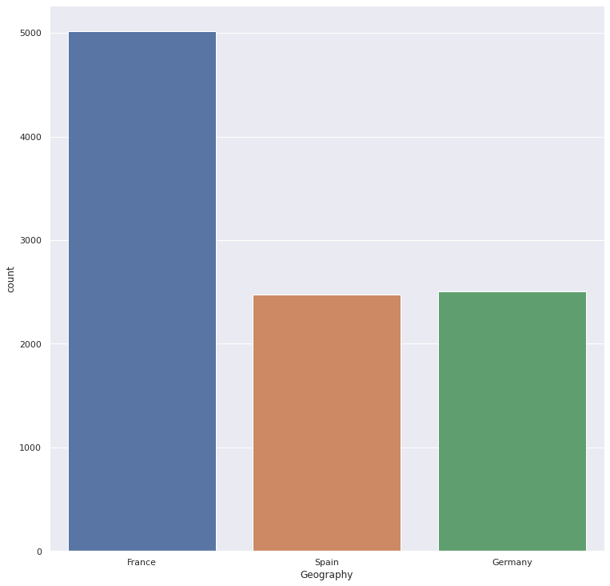

```
Number of customers who has France Geography: 5014
Number of customers who has Spain Geography: 2477
Number of customers who has Germany Geography: 2509
```

```python
make_count_plot(col_name="Geography",data=data)
```

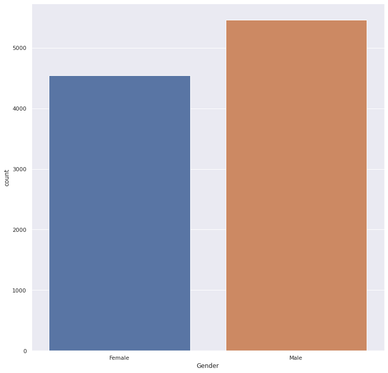

```
Number of customers who has Female Gender: 4543
Number of customers who has Male Gender: 5457
```

```python
make_count_plot(col_name="Gender",data=data)
```

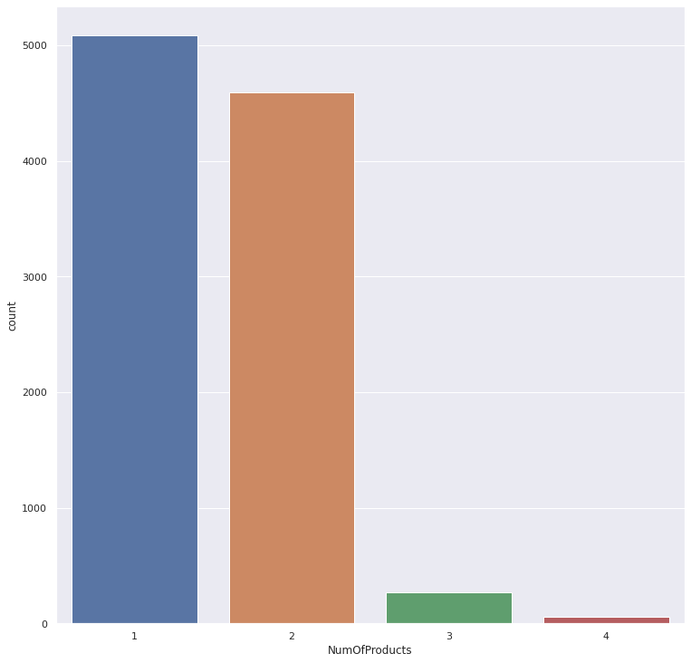

```
Number of customers who has 1 NumOfProducts: 5084
Number of customers who has 3 NumOfProducts: 266
Number of customers who has 2 NumOfProducts: 4590
Number of customers who has 4 NumOfProducts: 60
```

```python
make_count_plot(col_name="NumOfProducts",data=data)
```

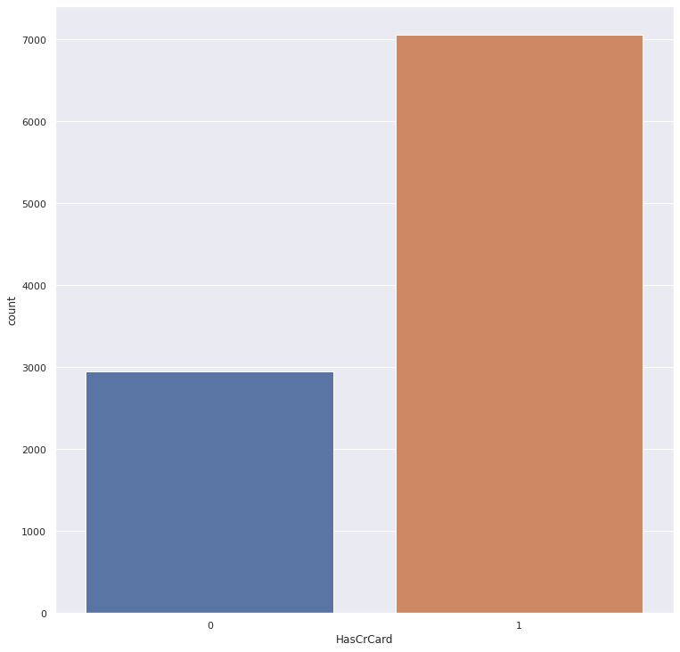

```
Number of customers who has 1 HasCrCard: 7055
Number of customers who has 0 HasCrCard: 2945
```

```python
make_count_plot(col_name="HasCrCard",data=data)
```

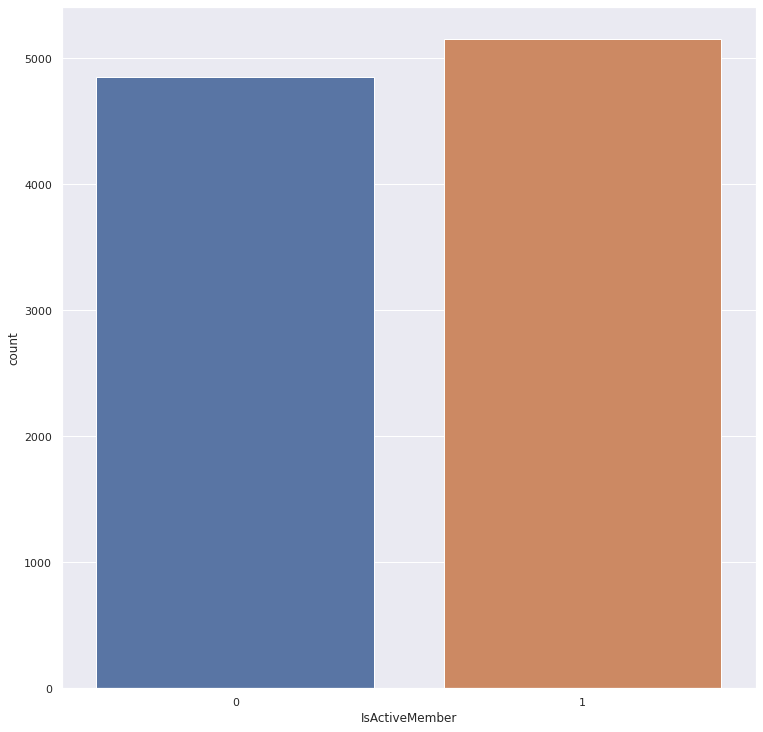

```
Number of customers who has 1 IsActiveMember: 5151
Number of customers who has 0 IsActiveMember: 4849
```

```python
make_count_plot(col_name="IsActiveMember",data=data)
```

# Checked whether the dataset is balanced or not

As we can see in the plot below, the number of exited members is much lesser than the total, hence we are dealing with unbalanced dataset here.

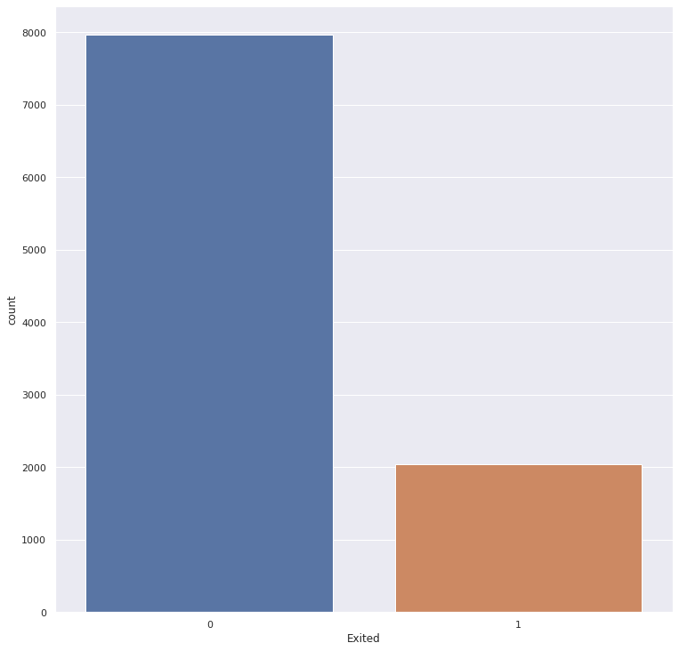

```
Number of customers who has 1 Exited: 2037
Number of customers who has 0 Exited: 7963
```

```python
make_count_plot(col_name="Exited",data=data)
```

```
Univariate Analysis of CreditScore
Max CreditScore is 850
Min CreditScore is 350
Mean CreditScore is 650.5288
```

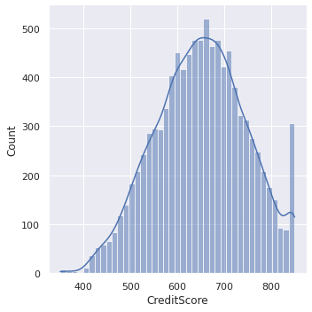

```python
make_distribution_plot(col_name="CreditScore",data=data)
```

```
Univariate Analysis of Age
Max Age is 92
Min Age is 18
Mean Age is 38.9218
```

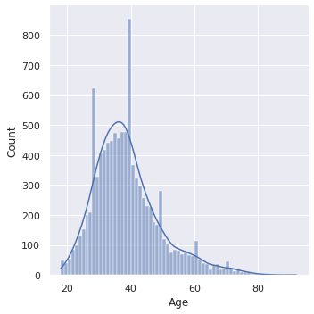

```python
make_distribution_plot(col_name="Age",data=data)
```

```
Univariate Analysis of Tenure
Max Tenure is 10
Min Tenure is 0
Mean Tenure is 5.0128
```

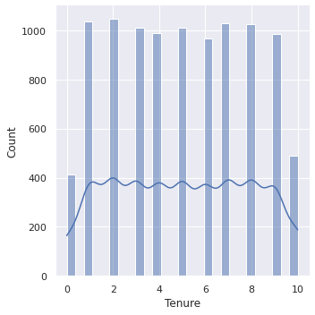

```python
make_distribution_plot(col_name="Tenure",data=data)
```

```
Univariate Analysis of Balance
Max Balance is 250898.09
Min Balance is 0.0
Mean Balance is 76485.88928799961
```

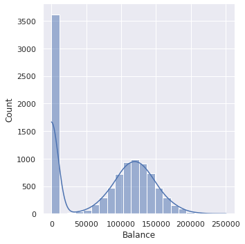

```python
make_distribution_plot(col_name="Balance",data=data)
```

```
Univariate Analysis of EstimatedSalary
Max EstimatedSalary is 199992.48
Min EstimatedSalary is 11.58
Mean EstimatedSalary is 100090.2398809998
```

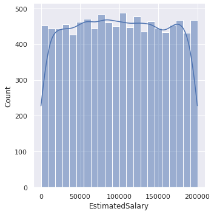

```python
make_distribution_plot(col_name="EstimatedSalary",data=data)
```

# Bi-Variate Analysis

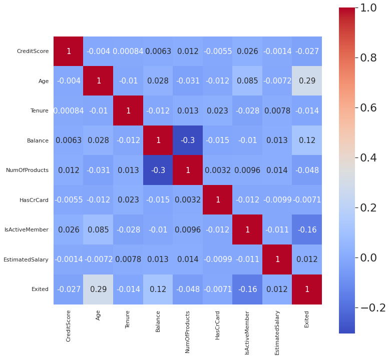

```python
make_heat_map(data=data)
```

# Observations from the correlation matrix (above)

- Decent +ve correlation between Age and Exited (Makes sense, with increase in age, the money will be taken and invested somewhere else).
- Decent -ve correlation between balance and number of products (makes sense, since more number of product you buy, the less balance might be, since it will be used on those products)
- Decent -ve correlation between IsActiveMember and Exited (makes sense, a person is more active, may not exit (since they are using the service).
- Decent +ve correlation between Exited and Balance (make sense, a person with high balance, might take that money and close the account, than just a dead money).

# Key meaningful Observation between Age and Exited

## Some observations from the plot below:

- People of higher ages have exited more than of younger members

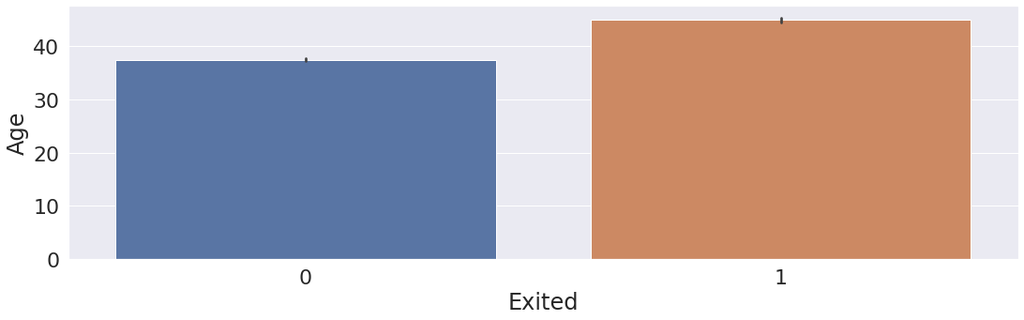

```python
draw_bar_plot(y=data["Age"],
              x=data["Exited"])
```

# Key meaningful Observation between CreditScore and Exited

## Some observations from the plot below:

- Nothing to report here.

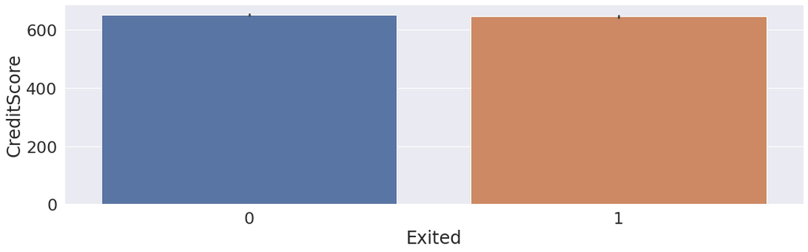

```python
draw_bar_plot(y=data["CreditScore"],
              x=data["Exited"])
```